# Unit 5 - Moving Average (MA(q)) and ARMA(p,q) Models

# For Live Session

In preparation for the next live session, please complete the following. Be sure and submit your work to the “Unit 5:”For Live Session" Assignment" assignment on 2DS:

- Use Aic5 to assess the use of ARMA models for your time series. Add your findings to the Google doc.

For the breakout PowerPoint slides:

- Slide 1: Use Aic5 to assess the use of ARMA models in the Walmart data.
- Slide 2: Find ρ1 for the following model by hand. Xt = at–.8at-1 + .5at–2.
- Slide 3: Represent the model as a GLP.
- Slide 4: Generate a realizations from an ARMA model. You pick p and q. Include the ACF and spectral density.
- Slide 5: Use AIC 5 to identify the top five quality models with respect to AIC for the cancelled flight data from the SWADelay.csv data set (column: arr_cancelled). Comment on which are AR, MA, and ARMA.
- Slide 6+: Provide a slide or slides for your Key Takeaways for Unit 5!
- Last slide: Provide a slide or slides for any questions or comments you have from this section. This could also include topics you would like to have specifically addressed in live session! There is no minimum or maximum here.

```r
library(tidyverse)
library(tswge)
```

# For Live Session

## Bikeshare Demand

```r
df_train <- read.csv(file="../../Unit 2/pre_live/data/train.csv", header = TRUE)

# df_train$datetime = as.POSIXct(df_train$datetime)

df_train$datetime = as.POSIXct(strptime(df_train$datetime, "%Y-%m-%d %H:%M:%S"))


df_train <- df_train %>%
  mutate(year = as.factor(format(datetime, format = "%Y")),
         month = as.numeric(format(datetime, format = "%m")),
         day = as.factor(format(datetime, format = "%d")),
         hour = as.factor(format(datetime, format = "%H")))
```

```r
df_dec_2012 <- df_train %>%
    filter(datetime >= "2012-12-01")
```

```r
aic5.wge(df_dec_2012$count)
```

```
## ---------WORKING... PLEASE WAIT...
##
##
## Five Smallest Values of  aic
```

|  | p | q | aic |
| --- | --- | --- | --- |
| 14 | 4 | 1 | 9.163965 |
| 17 | 5 | 1 | 9.165910 |
| 18 | 5 | 2 | 9.171964 |
| 16 | 5 | 0 | 9.211459 |
| 15 | 4 | 2 | 9.213106 |

## Walmart Data

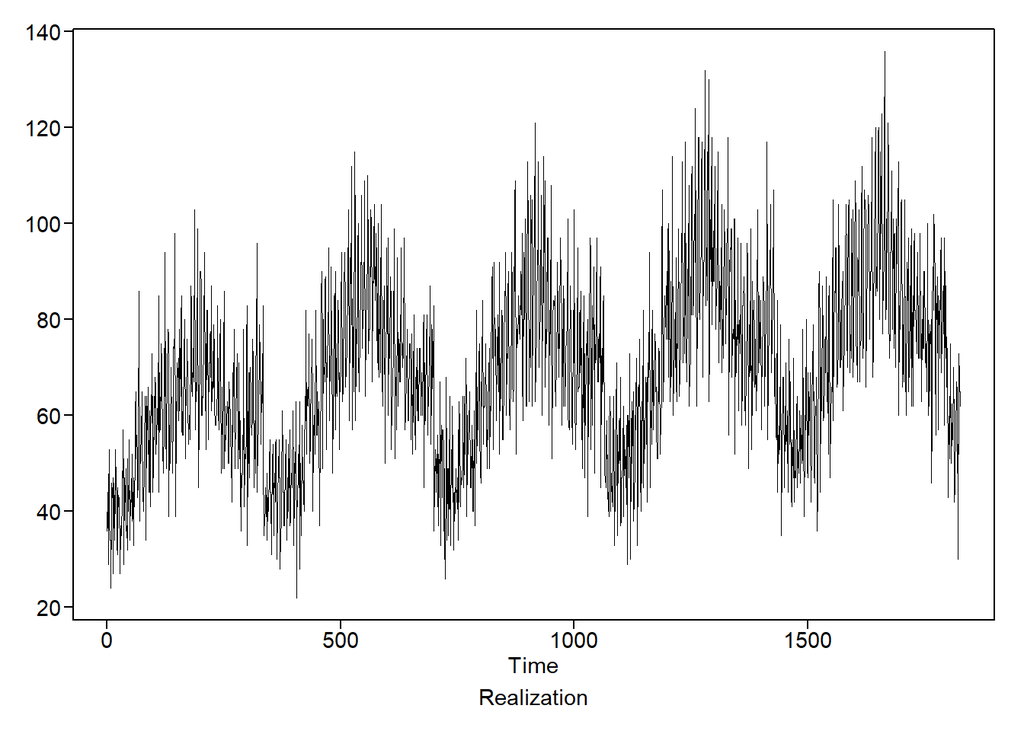

```r
#Walmart Analysis
# Walmart = read.csv(file.choose(),header = TRUE)
Walmart = read.csv(file="../../Unit 3/Walmart.csv", header = TRUE)


Store9Item50 = Walmart %>% filter(store == "9", item == "50")

plotts.wge(Store9Item50$sales)
```

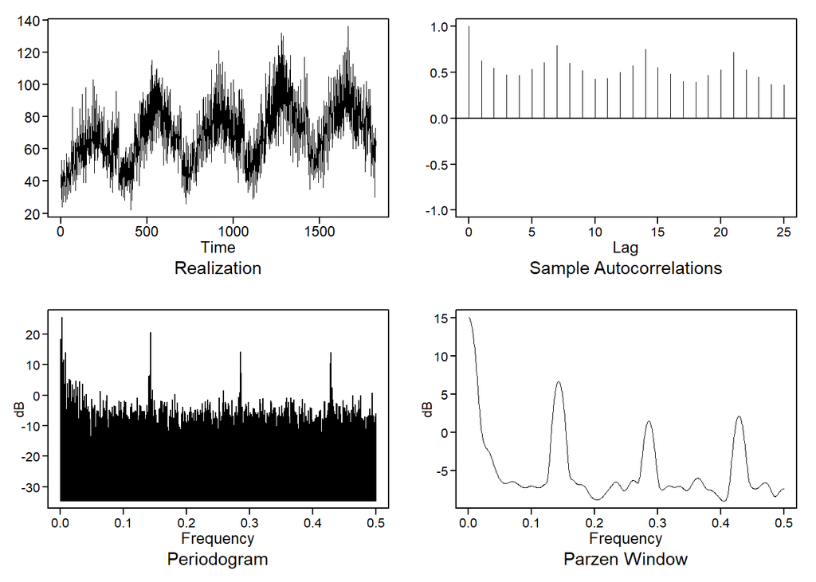

[output not shown]

[output cut: 515 more lines]

```r
plotts.sample.wge(Store9Item50$sales)
```

```r
aic5.wge(Store9Item50$sales)
```

```
## ---------WORKING... PLEASE WAIT...
##
##
## Five Smallest Values of  aic
```

|  | p | q | aic |
| --- | --- | --- | --- |
| 15 | 4 | 2 | 4.991650 |
| 17 | 5 | 1 | 5.009865 |
| 18 | 5 | 2 | 5.021469 |
| 14 | 4 | 1 | 5.073902 |
| 12 | 3 | 2 | 5.114417 |

```r
# parzen.wge(na.omit(Store9Item50$sales))
# parzen.wge(na.omit(Store8Item50$sales), trunc = 500)


# plotts.wge(SWA$weather_delay)
# plotts.sample.wge(SWA$weather_delay)

# aic5.wge(SWA$weather_delay)
```

## Rho 1 Calculation

### General Equation for rho 1

$$\begin{equation}
\rho_1 = \frac{-\theta_1 + \theta_1\theta_2}{1 + \theta_1^2 + \theta_2^2}
\end{equation}$$

### Actual Equation

```r
# X_t = a_t -.8a_t-1 + .5a_t-2

theta1 = .8
theta2 = -.5

p0 = 1
p1 = NA

p1 = (-(theta1) + (theta1 * theta2)) / (1 + (theta1^2 + theta2^2))
p1
```

```
## [1] -0.6349206
```

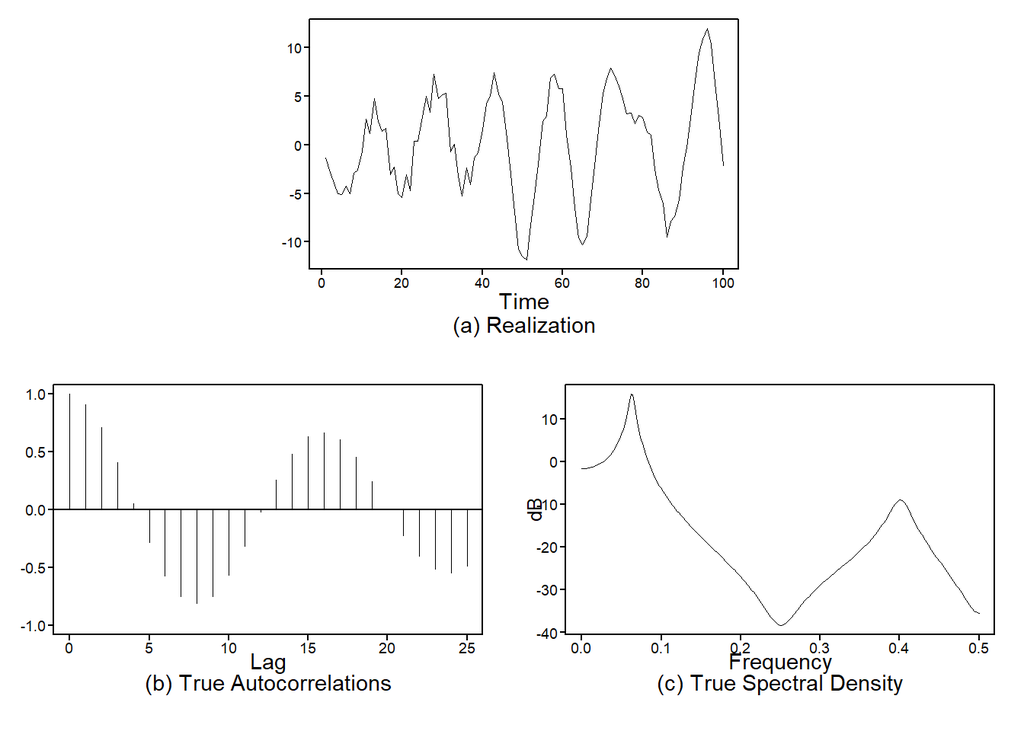

[output not shown]

[output cut: 69 more lines]

```r
# ARMA
plotts.true.wge(phi = c(.3, .9, .1, -.8075), theta = c(-.9, -.8, -.72))
```

```r
# factor.wge(c(.3, .9, .1, -.8075))
```

## SWA Cacelled Flights

Use AIC 5 to identify the top five quality models with respect to AIC for the cancelled flight data from the SWADelay.csv data set (column: arr_cancelled). Comment on which are AR, MA, and ARMA.

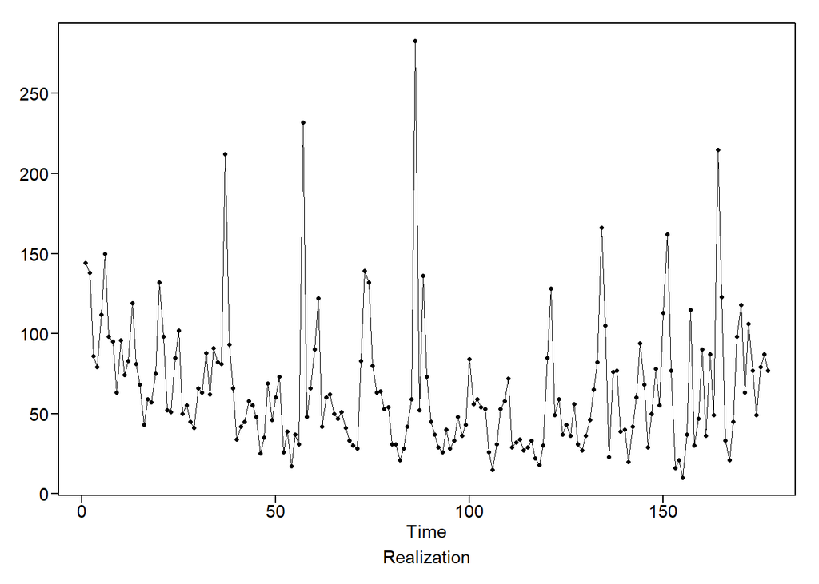

```r
# aic.wge(jetA$Price, p = 1, q = 0 )$value

# plotts.ege(jetA$Price)

# aic5.wge(jetA$price)

# SWA Delay Analysis

# SWA = read.csv(file.choose(), header = TRUE)
SWA = read.csv(file="../SWADelay.csv", header = TRUE)

plotts.wge(SWA$arr_cancelled)
```

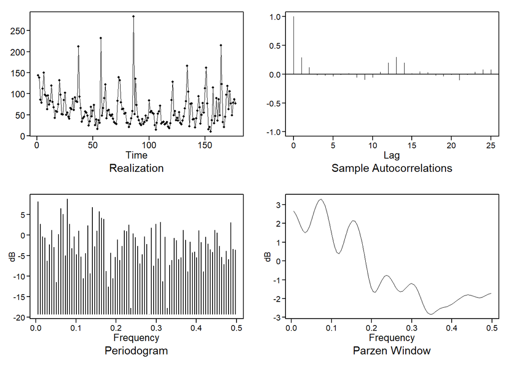

[output not shown]

[output cut: 42 more lines]

```r
plotts.sample.wge(SWA$arr_cancelled)
```

```r
aic5.wge(SWA$arr_cancelled)
```

```
## ---------WORKING... PLEASE WAIT...
##
##
## Five Smallest Values of  aic
```

|  | p | q | aic |
| --- | --- | --- | --- |
| 4 | 1 | 0 | 7.371886 |
| 3 | 0 | 2 | 7.376428 |
| 7 | 2 | 0 | 7.381147 |
| 5 | 1 | 1 | 7.381751 |
| 2 | 0 | 1 | 7.386961 |

# Asynchronous Material

## 5.2 MA(q): Properties and Characteristics, Part I

### 5.2.5 MA(1) Model

```r
# X_t = a_t -.5a_t-1


theta1 = .5

p0 = 1
p1 = NA
p2 = 0
p3 = 0


p1 = -(theta1) / (1 + theta1^2)
p1
```

```
## [1] -0.4
```

#### Equation for rho 1

$$\begin{equation}
\rho_1 = \frac{-\theta_1}{1 + \theta_1^2}
\end{equation}$$

### 5.2.7 MA(2) Model

```r
# X_t = a_t -.5a_t-1 + .9a_t-2


theta1 = .5
theta2 = -.9

p0 = 1
p1 = NA
p2 = NA
p3 = 0


p1 = (-(theta1) + (theta1 * theta2)) / (1 + (theta1^2 + theta2^2))
p1
```

```
## [1] -0.461165
```

```r
p2 = -(theta2) / (1 + (theta1^2 + theta2^2))
p2
```

```
## [1] 0.4368932
```

#### Equation for rho 1

$$\begin{equation}
\rho_1 = \frac{-\theta_1 + \theta_1\theta_2}{1 + \theta_1^2 + \theta_2^2}
\end{equation}$$

#### Equation for rho 2

$$\begin{equation}
\rho_2 = \frac{-\theta_2}{1 + \theta_1^2 + \theta_2^2}
\end{equation}$$

## 5.3 MA(q): Properties and Characteristics, Part II

### 5.3.1 tswge

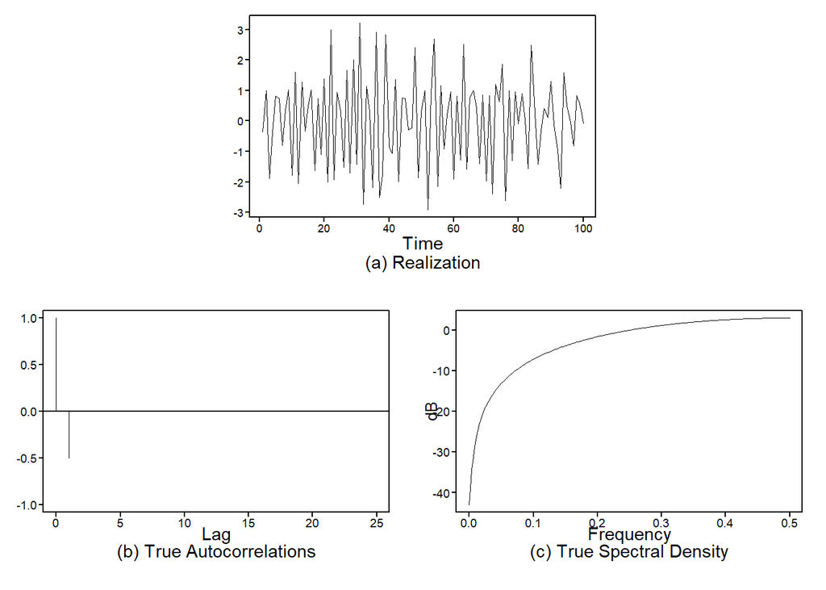

[output not shown]

[output cut: 72 more lines]

```r
# Generating MA(1) data

# gen.arma.wge(n=100, theta=.99)
# gen.arma.wge(n=100, theta=-.99)
# gen.arma.wge(n=100, theta=.99, sn=5)
# gen.arma.wge(n=100, theta=-.99, sn=5)
plotts.true.wge(theta=c(.99))
```

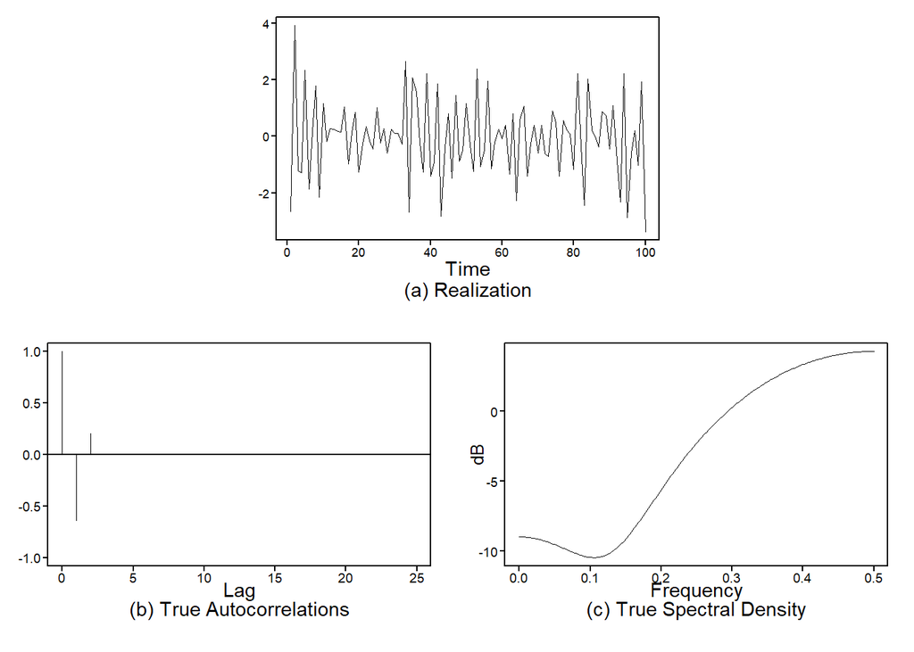

[output not shown]

[output cut: 72 more lines]

```r
# Generating MA(2) data from Example 2

# gen.arma.wge(n=100, theta=c(.9,-.4))
plotts.true.wge(theta=c(.9,-.4))
```